# STA6235: Chapter 2 Examples

Last updated: 2022-03-22

The Toluca Company manufactures refrigeration equipment as well as many replacement parts. In the past, one of the replacement parts has been produced periodically in lots of varying sizes. When a cost improvement program was undertaken, company officials wished to determine the optimum lot size for producing this part. The production of this part involves setting up the production process (which must be done no matter the lot size) and machining and assembly operations. One key input for the model to ascertain the optimum lot size was the relationship between lot size and labor hours required to produce the lot. To determine this relationship, data on lot size and work hours for 25 recent production runs were utilized. The production conditions were stable during the six-month period in which the 25 runs were made and were expected to continue to be the same during the next three years, the planning period for which the cost improvement program was being conducted. The data is as follows:

```r
# enter data
x <- c( 80,  30,  50,  90,  70,  60, 120,  80, 100,
        50,  40,  70,  90,  20, 110, 100,  30,  50,
        90, 110,  30,  90,  40,  80,  70)

y <- c(399, 121, 221, 376, 361, 224, 546, 352, 353,
       157, 160, 252, 389, 113, 435, 420, 212, 268,
       377, 421, 273, 468, 244, 342, 323)

# put together as tibble
one <- tibble(x, y)

datatable(one)
```

|  | x | y |
| --- | --- | --- |
| 1 | 80 | 399 |
| 2 | 30 | 121 |
| 3 | 50 | 221 |
| 4 | 90 | 376 |
| 5 | 70 | 361 |
| 6 | 60 | 224 |
| 7 | 120 | 546 |
| 8 | 80 | 352 |
| 9 | 100 | 353 |
| 10 | 50 | 157 |

[output cut: 15 more lines]

## Data Exploration

Let’s explore our data. Let us first create histograms of the variables we are exploring.

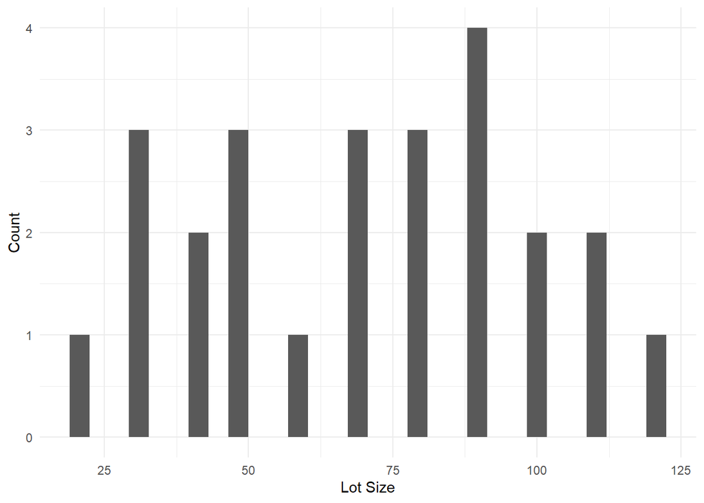

```r
one %>% ggplot(aes(x)) +
  geom_histogram() +
  xlab("Lot Size") +
  ylab("Count") +
  theme_minimal()
```

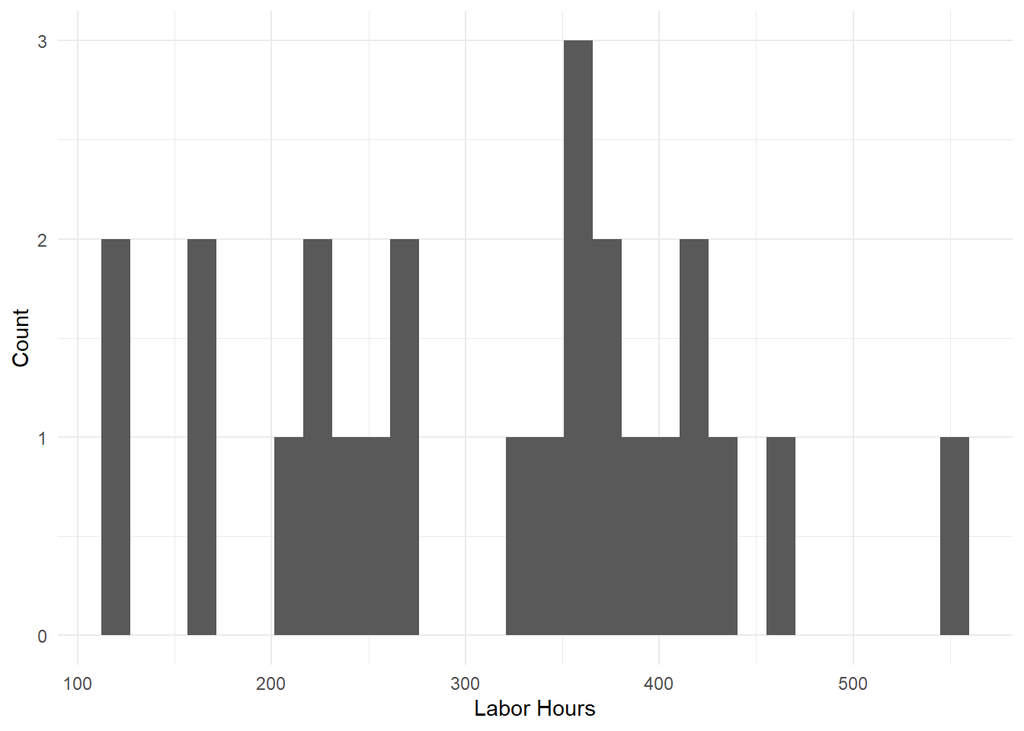

```r
ggplot(one, aes(y)) +
  geom_histogram() +
  xlab("Labor Hours") +
  ylab("Count") +
  theme_minimal()
```

We know we are interested in modeling the number of labor hours as a function of lot size. Let’s now look at a scatterplot of our data.

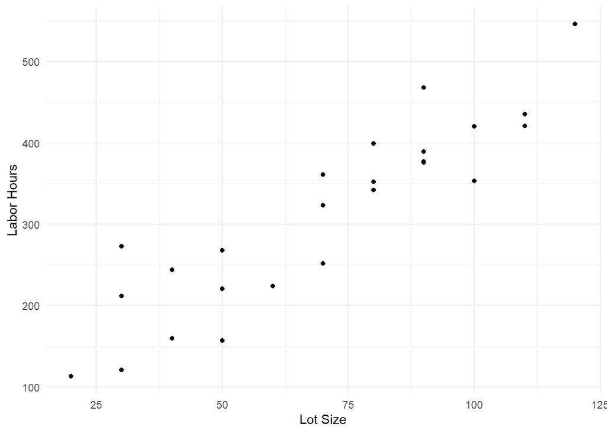

```r
ggplot(one, aes(x=x, y=y)) +
  geom_point() +
  xlab("Lot Size") +
  ylab("Labor Hours") +
  theme_minimal()
```

Next, we will examine summary statistics.

```r
# comment

means <- summarize(one, mean_x = mean(x, na.rm=TRUE), sd_x = sd(x, na.rm=TRUE), mean_y = mean(y, na.rm=TRUE), sd_y = sd(y, na.rm=TRUE))
```

The mean (standard deviation) lot size is 70 (28.72) lots. The mean (standard deviation) number of work hours is 312.28 (113.14) hours.

## Regression Model

Let’s now begin looking at our model.

```r
one_model <- lm(y ~ x, data = one)
one_summary <- summary(one_model)
one_coef <- coefficients(one_model)
one_ci <- as_tibble(confint(one_model, level=0.95))
```

The resulting regression model is
$$\hat{Y} = 62.37 + 3.57X$$

For an increase of 1 lot, we expect the number of labor hours to increase by 3.57 hours. The 95% confidence interval for this relationship is (2.85, 4.29).

If there are no lots to be produced, we expect the number of labor hours to be 62.37 hours.

## Test for $\beta_1$

Let us now determine if the number of labor hours is significantly predicted by lot size.

```r
one_t <- as_tibble(one_summary[[4]])
```

**Hypotheses**

$H_0: \ \beta_1 = 0$  
$H_1: \ \beta_1 \ne 0$

**Test Statistic**

$t_0 = 10.29$.

*p*-value

$p < 0.0001$.

**Rejection Region**

Reject if $p < \alpha$, where $\alpha=0.05$.

**Conclusion and Interpretation**

Reject $H_0$. There is sufficient evidence to suggest that labor hours is predicted by lot size.

## Correlation

Let’s now examine correlation between lot size and labor hours.

```r
one_corr_test0 <- cor.test(one$x, one$y, method="pearson")
```

The Pearson correlation between lot size and labor hours is 0.906. The 95% confidence interval for the correlation between lot size and labor hours is (0.797, 0.958). There is a strong positive correlation between lot size and labor hours.

Let us now test if the correlation is significantly different from 0.

**Hypotheses**

$H_0: \ \rho = 0$  
$H_1: \ \rho \ne 0$

**Test Statistic**

$t_0 = 10.29$.

*p*-value

$p < 0.0001$.

**Rejection Region**

Reject if $p < \alpha$, where $\alpha=0.05$.

**Conclusion and Interpretation**

Reject $H_0$. There is sufficient evidence to suggest that the correlation is non-zero.

## Visualization of Regression Line

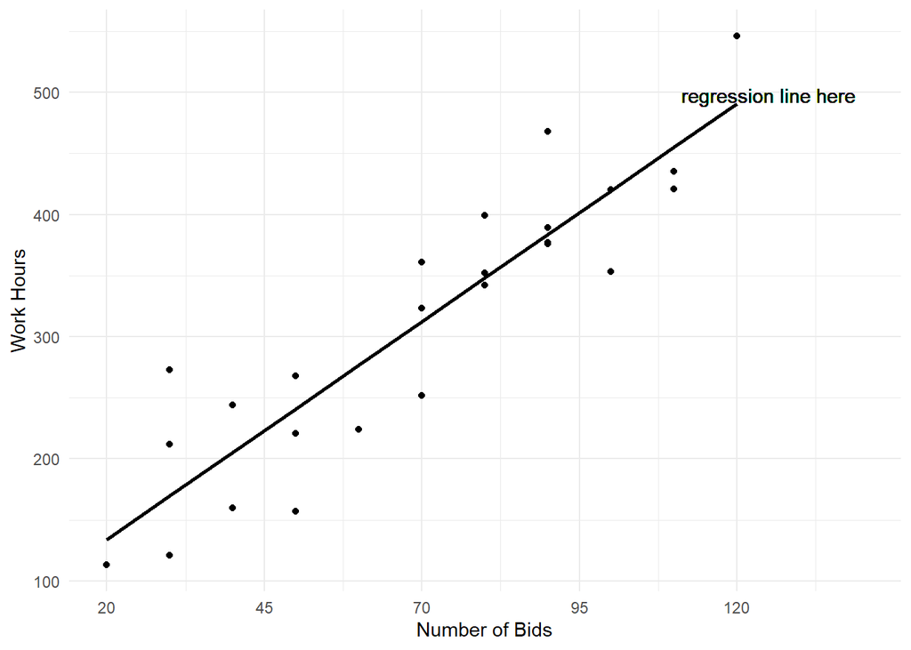

```r
one <- one %>% mutate(pred = predict(one_model))

one %>% ggplot(aes(x = x, y = y)) +
  geom_line(aes(y = pred), color = "black", size=1) +
  geom_point() +
  geom_text(aes(x = 125, y = 498, label = "regression line here"), color="black", show.legend = FALSE) +
  scale_x_continuous(lim = c(20, 140), breaks = seq(min(20), max(140), by = 25), minor_breaks = seq(min(20), max(140), by = 12.5)) +
  xlab("Number of Bids") +
  ylab("Work Hours") +
  theme_minimal()
```